```r
setwd('/home/lien/data/skrypty/TFIIB/')
library("tidyverse")
source('functions.R')
```

#### provide the path to GMatrix.RDS files

```r
data_dir='/home/lien/data/TFIIB/GEO_upload/HiC/'
```

### load the metadata for Hi-C samples

```r
sample_info <- read_tsv('/home/lien/data/skrypty/TFIIB/samples_GEO_HiC.tsv',col_types='ffffff')
sample_info
```

```
## # A tibble: 12 × 6
##    sample   genotype condition brep  stress  plants
##    <fct>    <fct>    <fct>     <fct> <fct>   <fct>
##  1 Sample1  Wt       NT        r1    water   naive
##  2 Sample2  Wt       S1        r1    drought naive
##  3 Sample3  Wt       R         r1    water   trained
##  4 Sample4  Wt       S2        r1    drought trained
##  5 Sample5  R58C     NT        r1    water   naive
##  6 Sample6  R58C     S1        r1    drought naive
##  7 Sample7  R58C     R         r1    water   trained
##  8 Sample8  R58C     S2        r1    drought trained
##  9 Sample9  Wt       NT        r2    water   naive
## 10 Sample10 Wt       S1        r2    drought naive
## 11 Sample11 Wt       R         r2    water   trained
## 12 Sample12 R58C     S1        r2    drought naive
```

### only Sample1 will be analysed

```r
s='1'
```

### prepare the lists of genes: from 3 to 50kb, exclusively present in each of groups from PCSD database

### that are enriched in the gene-body region is chromatin states S3, S12, S25 or S26

```r
group_sets=list('geneBody'=c(3,12,25,26))
down_thresh=3000
up_thresh=50000
Groups <- create_Groups(group_sets,down_thresh,up_thresh,complement_rest=F,exclusive=T)
```

### Create a unique directory to save matrix files and reports

```r
barcode=paste0(paste0(sample(c(letters,LETTERS),5,replace=T),collapse=""),as.integer(as.POSIXct(Sys.time())))
output_path = paste0(barcode,'/')
system(paste0('mkdir ',output_path),intern=F)
```

### Calculate meta-gene matrizes for specified groups and samples. Immediately save the results as symmetric matrices.

### Both raw and distance-normalized matrixes are generated

```r
metamatrix_data_4A <- lapply(1:length(Groups),function(G){
  genes=Groups[[G]]
  result <- calculate_metamatrix(genes,s)
  result$sample=paste0('Sample',s)
  result$name <- unite(sample_info,c(2:4),col='name',sep='_' )[which(sample_info$sample==result$sample),] %>% pull(name)
  result$group=names(Groups)[G]
  title=paste0(result$sample,'_',result$group,'_',down_thresh/1000,' kb to ',up_thresh/1000,' kb.matrix')
  write.table(result$mat_raw, file=paste0(output_path,'Meta_raw_',title), sep='\t', row.names = F, col.names =  F)
  write.table(result$mat_norm, file=paste0(output_path,'Meta_norm_',title), sep='\t', row.names = F, col.names =  F)
  return(result)
})
```

### Plot the first gene group from the first sample

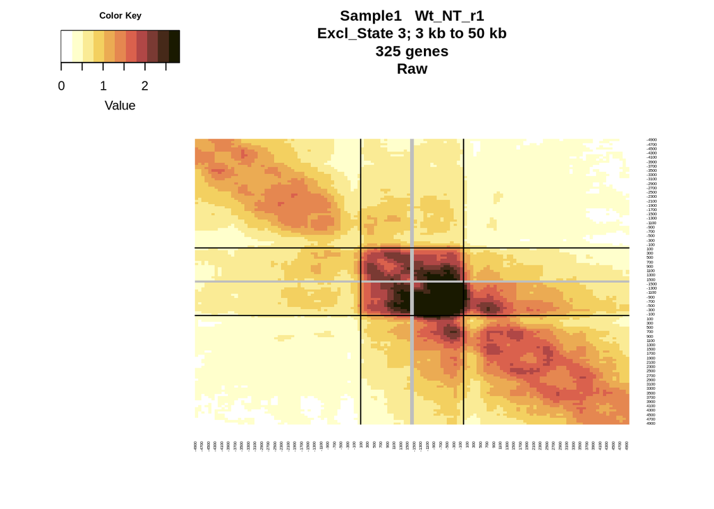

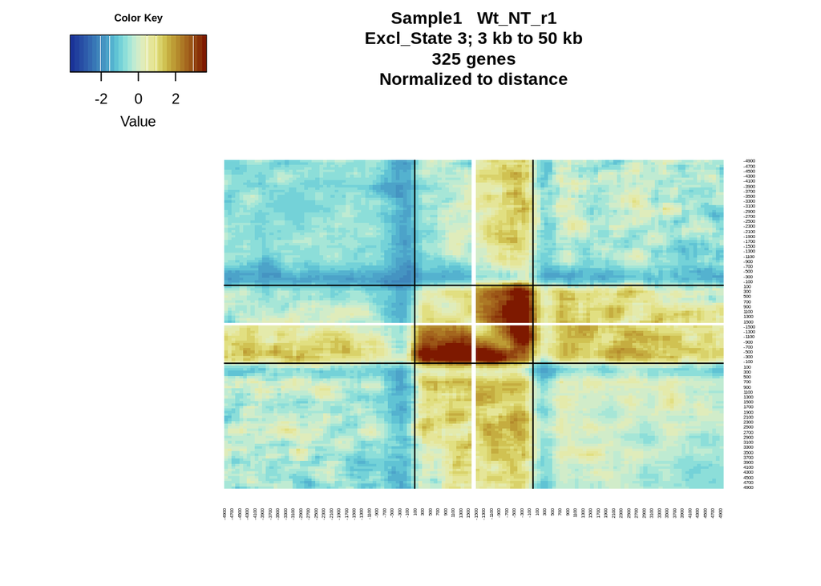

```r
x=metamatrix_data_4A[[1]]
title=paste0(x$sample,'   ',x$name,'\n',x$group,'; ',down_thresh/1000,' kb to ',up_thresh/1000,' kb\n',x$nr_of_genes,' genes')
f_draw_matrix(raw_array=x$mat_raw, norm_array=x$mat_norm,title=title,threshold=0.99)
```

### set the common scale for heatmaps

```r
threshold=0.99
max_norm = quantile(abs(scale(unlist(lapply(metamatrix_data_4A,function(x){x$'mat_norm'})))),probs=threshold,na.rm=T)
```

### create a pdf report with all heatmaps

```r
 pdf_file=paste0(output_path,paste0(unlist(group_sets),collapse='_'),'.pdf')
 pdf(pdf_file)
lapply(metamatrix_data_4A, function(x){
  title=paste0(x$sample,'   ',x$name,'\n',x$group,'; ',down_thresh/1000,' kb to ',up_thresh/1000,' kb\n',x$nr_of_genes,' genes')
     f_draw_matrix(raw_array=x$mat_raw, norm_array=x$mat_norm,title=title,threshold=threshold,max_scale_norm=max_norm)
})
```

```r
dev.off()
```

### Fig. 4A, lower panels - mean asymmetry ratios in each sample

### Pull the data from *sectors.tsv files

```r
sector_data <- lapply(1:12,function(i){
  read_tsv(paste0('/home/lien/data/TFIIB/GEO_upload/HiC/Sample',i,'_sectors.tsv'), col_types='cdddc')
}) %>% reduce(bind_rows)
```

### prepare the lists of genes: from 3 to 50kb, exclusively present in each of groups from PCSD database that are enriched in the gene-body region is chromatin states S3, S12, S25 or S26 + all protein coding genes

```r
group_sets=list('geneBody'=c(3,12,25,26), 'other'='All_PCG')
down_thresh=3000
up_thresh=50000
Groups <- create_Groups(group_sets,down_thresh,up_thresh,complement_rest=F,exclusive=T)
```

### calculate mean asymmetry ratio for each group of genes, for each sample

```r
summary <- make_contact_summary(data=sector_data,Groups)
```

### create plots

```r
plots <- report_contact_summary(summary,Groups)
```

```
## $`Sectors_Excl_State 3`
```

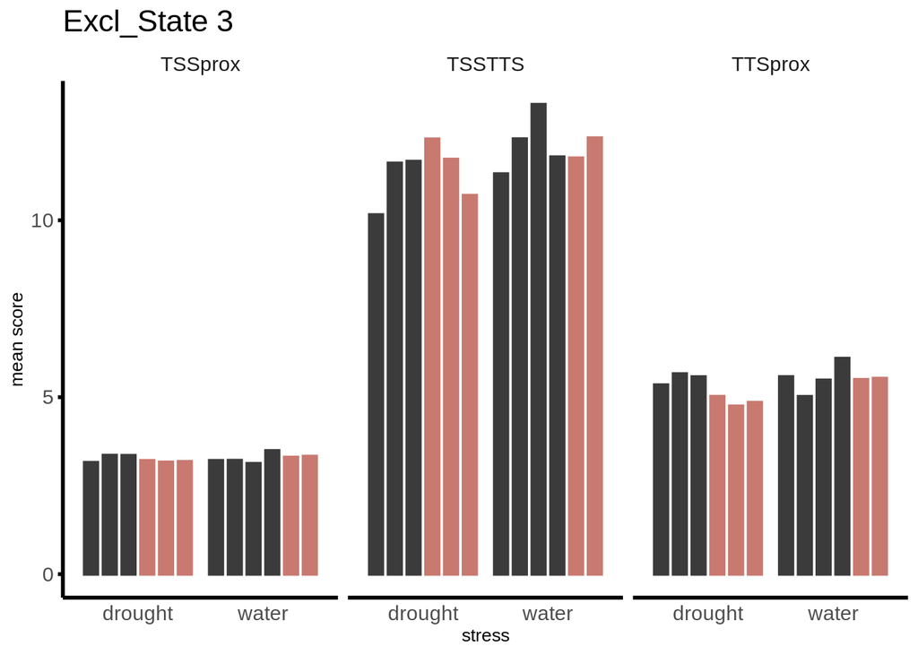

```
##
## $`Sectors_Excl_State 12`
```

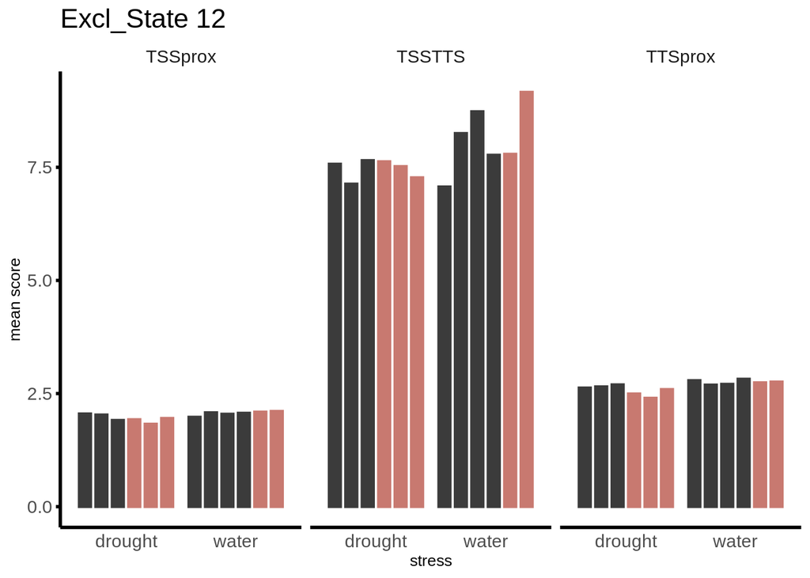

```
##
## $`Sectors_Excl_State 25`
```

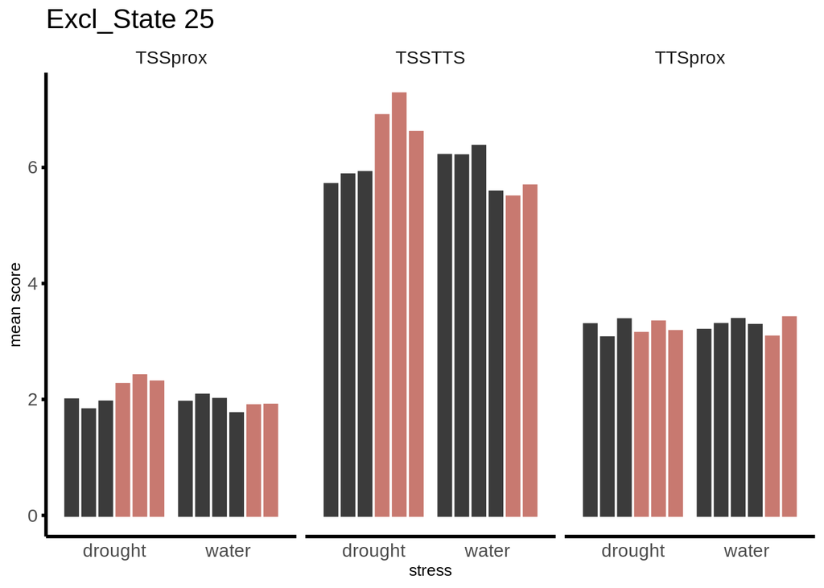

```
##
## $`Sectors_Excl_State 26`
```

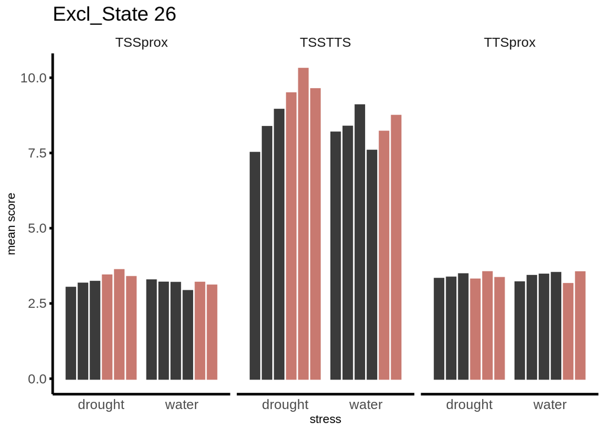

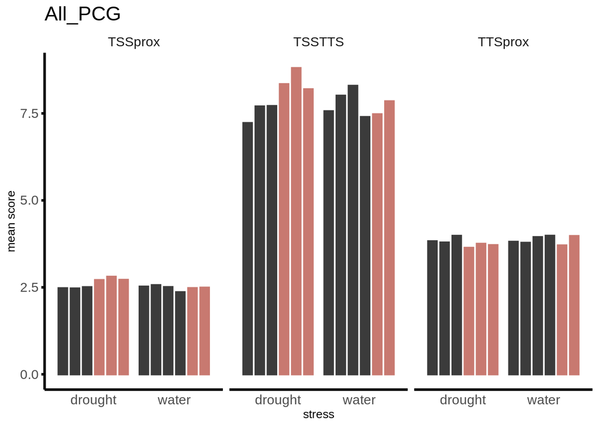

```
##
## $`AsymmetryRatio_Excl_State 3`
```

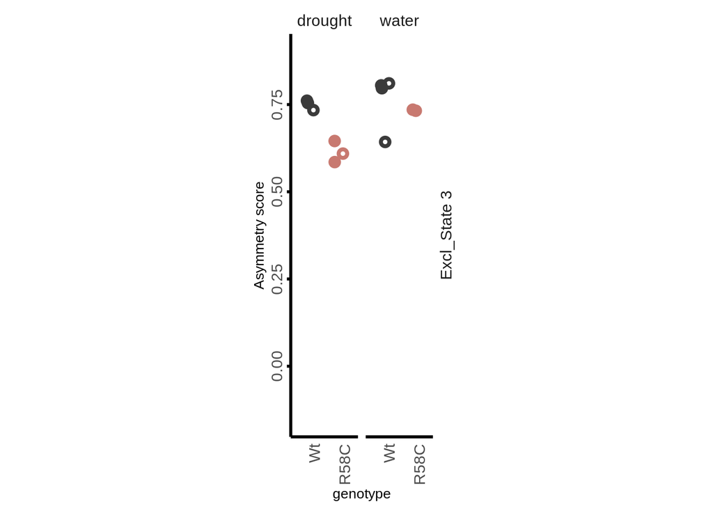

```
##
## $`AsymmetryRatio_Excl_State 12`
```

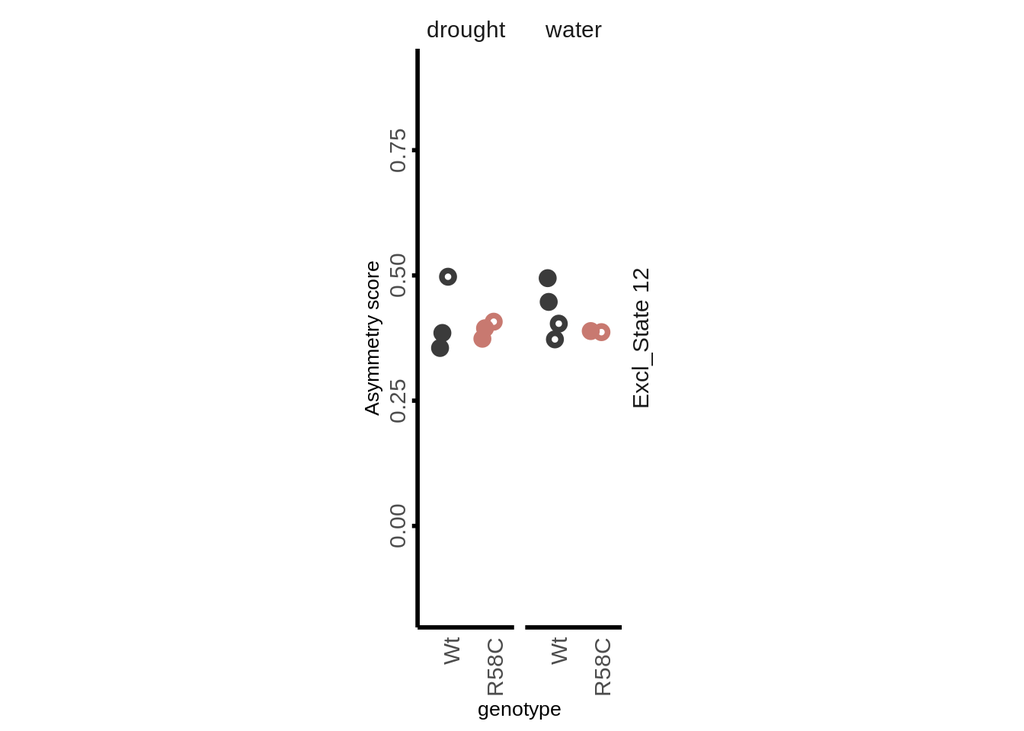

```
##
## $`AsymmetryRatio_Excl_State 25`
```

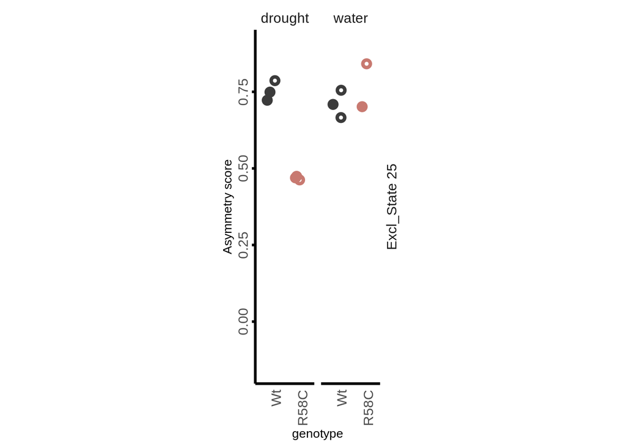

```
##
## $`AsymmetryRatio_Excl_State 26`
```

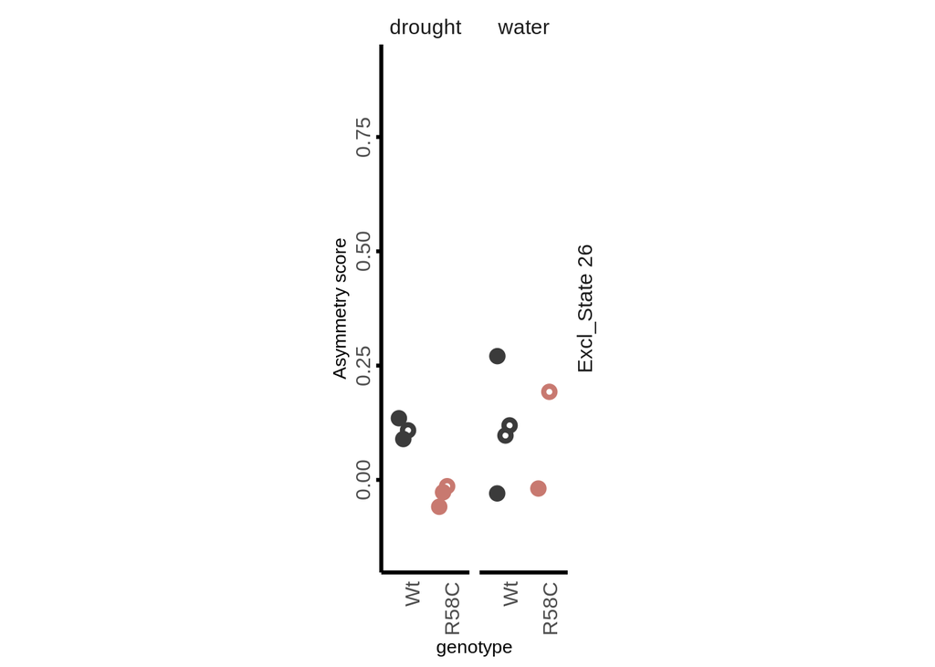

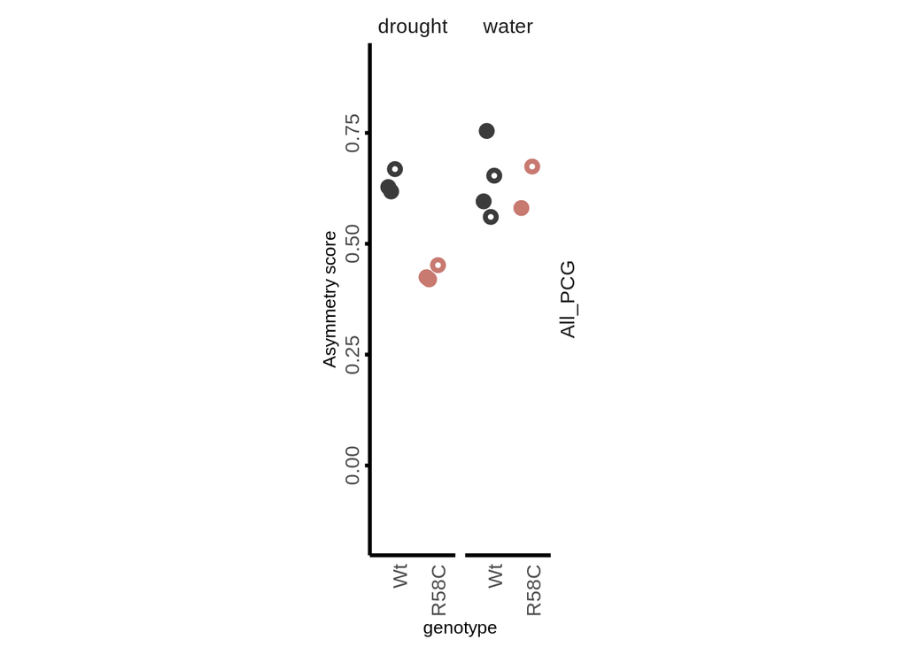

```
##
## $`Stats_Excl_State 3`
```

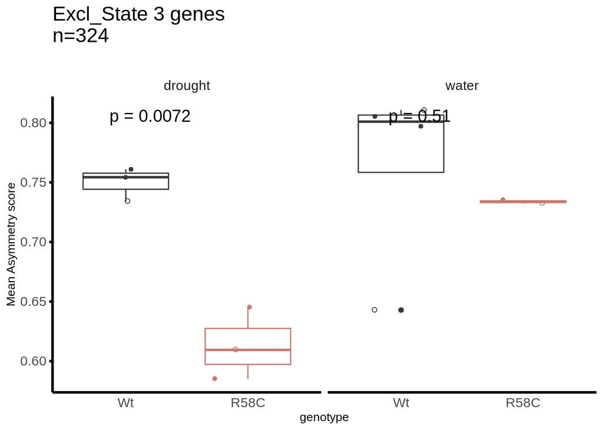

```
##
## $`Stats_Excl_State 12`
```

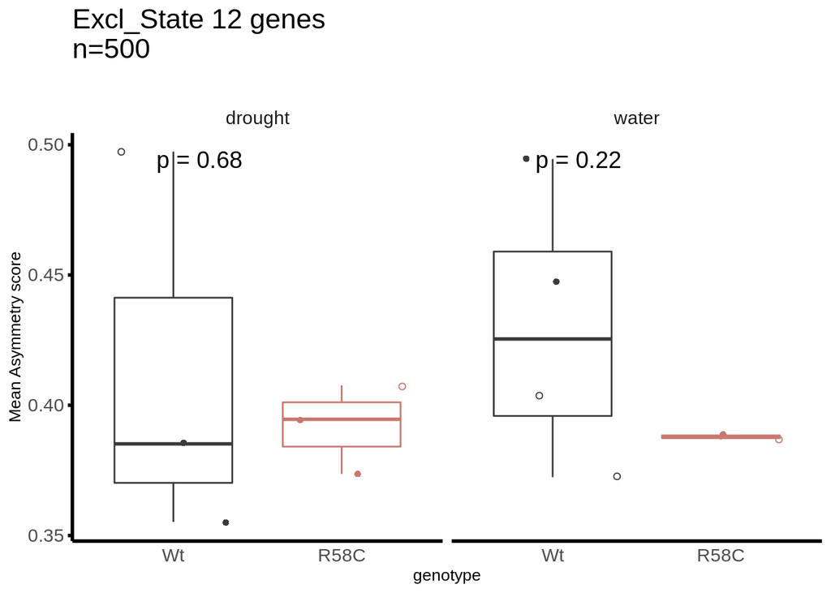

```
##
## $`Stats_Excl_State 25`
```

[4 more figures not shown]

[output not shown]

[output cut: 49 more lines]

```r
plots$boot_plot <- bootANDplot(data=sector_data,Groups,merge_samples=c(1,9))

lapply(plots,function(x){x})
```

### make a pdf report with all plots and table-summary

```r
pdf_name=paste0(output_path, 'AsymRatio_Fig4AB.pdf')
pdf(pdf_name,width = 4, height = 4)
print(plots)
```

```
## $`Sectors_Excl_State 3`
```

```
##
## $`Sectors_Excl_State 12`
```

```
##
## $`Sectors_Excl_State 25`
```

```
##
## $`Sectors_Excl_State 26`
```

```
##
## $`AsymmetryRatio_Excl_State 3`
```

```
##
## $`AsymmetryRatio_Excl_State 12`
```

```
##
## $`AsymmetryRatio_Excl_State 25`
```

```
##
## $`AsymmetryRatio_Excl_State 26`
```

```
##
## $`Stats_Excl_State 3`
```

```
##
## $`Stats_Excl_State 12`
```

```
##
## $`Stats_Excl_State 25`
```

```
##
## $`Stats_Excl_State 26`
```

```
##
## $boot_plot
## $boot_plot[[1]]
```

[output not shown]

[output cut: 49 more lines]

```r
lapply(names(Groups),function(x){
  table <- summary %>% select(group, sample,mean_AsRatio) %>%
    subset(group==x)%>%
    tableGrob(theme=ttheme_default(base_size=6))
   grid.newpage()
  grid.draw(table)
})
```

```r
dev.off()
```

```r
### plots can be saved as .svg
# lapply(1:length(plots),function(x){
#   svg(paste0(output_path,x,'.svg'),width = 4, height = 4)
#   print(plots[[x]])
#   dev.off()
# })
```

### plot expersion for these groups of genes, based on 3’RNA-seq data

### load metadata for 3’RNA-seq data samples and counts_table

```r
sample_info_3RNAseq <- read_tsv('sample_info_3RNAseq.tsv', col_types ='cffdffff') %>%
  mutate(comparison=paste0(stress,'_',timepoint),
         genotype=factor(genotype, levels=c('Wt','R58C')))
sample_info_3RNAseq
```

```
## # A tibble: 36 × 9
##    sample        genotype stress timepoint replicate red_sample condition plants
##    <chr>         <fct>    <fct>      <dbl> <fct>     <fct>      <fct>     <fct>
##  1 R58C_S1_0_1   R58C     S1             0 r1        R58C_S1_0  Non_trea… naive
##  2 R58C_S1_0_2   R58C     S1             0 r2        R58C_S1_0  Non_trea… naive
##  3 R58C_S1_0_3   R58C     S1             0 r3        R58C_S1_0  Non_trea… naive
##  4 R58C_S1_90_1  R58C     S1            90 r1        R58C_S1_90 Primary … naive
##  5 R58C_S1_90_2  R58C     S1            90 r2        R58C_S1_90 Primary … naive
##  6 R58C_S1_90_3  R58C     S1            90 r3        R58C_S1_90 Primary … naive
##  7 R58C_S1_180_1 R58C     S1           180 r1        R58C_S1_1… Primary … naive
##  8 R58C_S1_180_2 R58C     S1           180 r2        R58C_S1_1… Primary … naive
##  9 R58C_S1_180_3 R58C     S1           180 r3        R58C_S1_1… Primary … naive
## 10 R58C_S4_0_1   R58C     S4             0 r1        R58C_S4_0  Recovery  train…
## # … with 26 more rows, and 1 more variable: comparison <chr>
```

```r
nor <- read_tsv('readCounts_table.tsv',col_types=paste0('c',paste0(rep('d',36),collapse='')))
head(nor,10)
```

```
## # A tibble: 10 × 37
##    GeneID    Wt_S1_0_1 Wt_S1_0_2 Wt_S1_0_3 Wt_S1_90_1 Wt_S1_90_2 Wt_S1_90_3
##    <chr>         <dbl>     <dbl>     <dbl>      <dbl>      <dbl>      <dbl>
##  1 AT1G01010         1         0         3          1          2          4
##  2 AT1G01020        15         8         1          5         21         10
##  3 AT1G01030         2         0         0          2          4          4
##  4 AT1G01040        13        11         3         15         20         13
##  5 AT1G01050        95       108        31         78        161        110
##  6 AT1G01060       193       139        67         36        121         58
##  7 AT1G01070        26         6         8          5         19          7
##  8 AT1G01080        67        71        26         53         89         58
##  9 AT1G01090       137       111        48        100        219        137
## 10 AT1G01100       619       530       327        376        845        545
## # … with 30 more variables: Wt_S1_180_1 <dbl>, Wt_S1_180_2 <dbl>,
## #   Wt_S1_180_3 <dbl>, R58C_S1_0_1 <dbl>, R58C_S1_0_2 <dbl>, R58C_S1_0_3 <dbl>,
## #   R58C_S1_90_1 <dbl>, R58C_S1_90_2 <dbl>, R58C_S1_90_3 <dbl>,
## #   R58C_S1_180_1 <dbl>, R58C_S1_180_2 <dbl>, R58C_S1_180_3 <dbl>,
## #   Wt_S4_0_1 <dbl>, Wt_S4_0_2 <dbl>, Wt_S4_0_3 <dbl>, Wt_S4_90_1 <dbl>,
## #   Wt_S4_90_2 <dbl>, Wt_S4_90_3 <dbl>, Wt_S4_180_1 <dbl>, Wt_S4_180_2 <dbl>,
## #   Wt_S4_180_3 <dbl>, R58C_S4_0_1 <dbl>, R58C_S4_0_2 <dbl>, …
```

### calculate rpm, average of biological replicates and take only data from TFIIB1-WT nontreated sample

```r
mean_rpms <- calculate_mean_rpm(nor, filter_nuclear=T, filter_protCoding=T)
WT_NT_mean_rpm <- mean_rpms[c('GeneID','Wt_S1_0')]
```

### divide genes into groups and remove genes that were not detected

```r
expression_data <- lapply(names(Groups),function(g){
WT_NT_mean_rpm %>%
  subset(GeneID %in% Groups[[g]])%>%
    subset(Wt_S1_0>0) %>%
  mutate(group=g)
}) %>% purrr::reduce(bind_rows)
```

### set the same colors as on asymmetry boot_plot

```r
kolory<- c("#8C0172", "#97523A","#4e4e4e","#99A021", "#29bc7e")
expression_data$group <- factor(expression_data$group, levels=c("Excl_State 26","Excl_State 12", "All_PCG","Excl_State 25", "Excl_State 3" ))
```

### plot the results

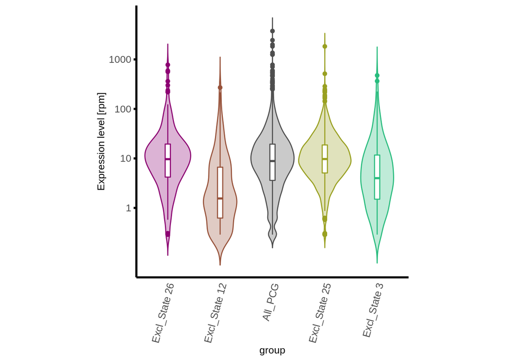

```r
expression_data %>%
  ggviolin(x="group",y="Wt_S1_0",alpha=0.3,color='group',fill='group') +
  scale_color_manual(values=kolory, aesthetics = c("color","fill"))+
   scale_y_log10(name='Expression level [rpm]',breaks=c(1,10,100,1000), labels=c('1','10','100','1000'))+
  #ylim(0,100)+
  scale_x_discrete(limits=c("Excl_State 26","Excl_State 12", "All_PCG","Excl_State 25", "Excl_State 3" ))+
   geom_boxplot(aes(x=group,y=Wt_S1_0,color=group),width=0.1)+
  newtheme+
  theme( aspect.ratio=1,
         #strip.text=element_blank(),
         axis.title=element_text(size = 10),
         axis.text=element_text(size = 10),
         axis.text.x=element_text(angle = 75,hjust=1))
```